# A. Maths and Feature Engineering

## 1. MSE

$$ E\big[ (\hat{\beta} - \beta)^2 \big] = \underbrace{Var[\hat{\beta}]}_{Variance} + \underbrace{\big( E(\hat{\beta}) - \beta \big)^2}_{Bias^2}$$

As the above equation shows,

- bias represents the squared distance betweem the expectation of estimates and the true value.
- Variance is the variance of the estimate. There should also be an irreducible error, which captures the noises and randomness and cannot be eliminated.

### a) Q: can there exist an estimator with the smaller MSE than minimal least squares?

**Answer:**

**No**. The Least Square Estimator is designed to minimise the Squared Error *per se* for the regression method, MSE is monotonous to the Squared Error.

$$\hat{\beta}|_{LSEstimator} = arg\min_{\beta} \sum \big( y-\hat{y} \big)^2$$

, where $\hat{\beta}|_{LSEstimator}$ is the least squared estimator; $y$ is the true value; $\hat{y}$ is the estimated value using the least squared estimate.

Clearly as the above formula shows, there cannot be anyother estimators that produce even smaller MSE than the Least Squared Estimator, because the Least Squared Estimator already mathematically do that.

### b) Q: for a prediction, does the MSE measure an irreducible error or model error?

**Answer:**

**No**. As the formula shows, MSE measures the squared distance between the estimate and the true value. However, irreducible error represents the randomness or noises that cannot be fully eliminated.

## 2. Entropy

$$H(X) = -\sum_{i=1}^{n} P(x_i) \log P(x_i)$$

, where

- $H(X)$ is the **entropy** of a random variable $X$.
- $P(x_i)$ denotes the probability of each possible outcome $x_i$ of $X$.
- $n$ is the total number of possible outcomes of $X$.

The above equation is the formula for Entropy. Entropy is the measure of uncertainty of a random variable.

Low Entropy means low uncertainty, *vice versa*. The partition effectively separates classes, and means more certain for the classification.

The higher the entropy is, the more uncertainty is, and the partition is less effective.

### a) Q: high entropy means the partitions are pure

**Answer:**

**False**. High Entropy means the classes is more evenly classified. In other words, there is higher uncertainty to identify the class. In this case, the partitions are less pure, as there is greater uncertainty in assigning a class label.

### b) Q: high entropy means the partitions are not pure.

**Answer:**

**True**. If the wording "Not Pure" means "Less Pure", then my answer is **True**. The reason is in the context of high entropy, there are more uncertainty, and it's hard to classify classes, and give the instance a certain label. Therefore, the partitions are less/not pure.

### Load Packages & Retrive Data

```python
import numpy as np
import pandas as pd
import matplotlib.pyplot as plt
import seaborn as sns

plt.style.use('fivethirtyeight')

# Ignore warnings
import warnings
warnings.filterwarnings('ignore')


import yfinance as yf
```

Here we use the S&P500 as the dataset. Data are retrived from 2017 to the most current date, and downloaded from yahoo finance. To avoid the lag and potential errors of downloading, I have same a .csv file in the same folder. Thus, loading data from the localhost would be alright.

```python
# df = yf.download('^GSPC')

# df = df[df.index>'2017']
# df.to_csv('SP500.csv')

df = pd.read_csv('SP500.csv', index_col=0, parse_dates=True)
```

### Summary Statistics

```python
df['r'] = df['Adj Close'].pct_change()
df.describe().T
```

|  | count | mean | std | min | 25% | 50% | 75% | max |
| --- | --- | --- | --- | --- | --- | --- | --- | --- |
| Open | 1615.0 | 3.333277e+03 | 7.191771e+02 | 2.251570e+03 | 2.728395e+03 | 3.114660e+03 | 3.995645e+03 | 4.804510e+03 |
| High | 1615.0 | 3.352414e+03 | 7.248549e+02 | 2.263880e+03 | 2.742415e+03 | 3.128440e+03 | 4.018990e+03 | 4.818620e+03 |
| Low | 1615.0 | 3.312515e+03 | 7.133196e+02 | 2.191860e+03 | 2.711310e+03 | 3.099260e+03 | 3.957525e+03 | 4.780040e+03 |
| Close | 1615.0 | 3.333717e+03 | 7.193897e+02 | 2.237400e+03 | 2.727740e+03 | 3.115860e+03 | 3.991485e+03 | 4.796560e+03 |
| Adj Close | 1615.0 | 3.333717e+03 | 7.193897e+02 | 2.237400e+03 | 2.727740e+03 | 3.115860e+03 | 3.991485e+03 | 4.796560e+03 |
| Volume | 1615.0 | 4.104008e+09 | 1.039787e+09 | 1.296530e+09 | 3.435730e+09 | 3.887250e+09 | 4.512265e+09 | 9.976520e+09 |
| r | 1614.0 | 4.753250e-04 | 1.251262e-02 | -1.198406e-01 | -3.916078e-03 | 7.062834e-04 | 6.307500e-03 | 9.382774e-02 |

### Creating Labels & Features

#### The label y is defined as below.

$$ y_t = \begin{cases} 1, & \text{if}\ \ p_{t+1}>0.9975 \times p_t \\ 0, & \text{Otherwise} \end{cases} $$

#### Features are as the following,

- O-C, H-L: Open - Close, High - Low
- sign: $sign(r_t)$
- PastReturn*i: $r*{t-1}, r_{t-2}, \cdots$
- Momenturn: $P_t - P_{t-k}$
- SMA_i: $SMA_i = \frac{1}{n}\sum_{i=0}^{n-1}P_{t-i}$
- Exponential MA: $EMA_i = EMA_{t-1} + \alpha [P_t - EMA_{t-1}]$

```python
# O-C  H-L
df['O-C'] = df.Open - df.Close
df['H-L'] = df.High - df.Low

# Sign
df['sign'] = np.sign(np.log(df['Adj Close']).diff())

# We create those following features, trying to capture the seasonality, and relative long term movement.
lag_list = [i for i in range(1,11)]
for i in lag_list:

    # Past Return
    df[f'PastReturn_{str(i)}'] = df.r.shift(i)

    # Momentum
    df[f'Momentum_{str(i)}'] = df['Adj Close'].diff(i)

    # Moving Average
    df[f'SMA_{str(i)}'] = df['Adj Close'].rolling(window=i).mean()

# Exponential MA
alpha = 2 / (1 + len(df))
df['EMA'] = df['Adj Close'][0]
for i in range(1, len(df)):
    df.iloc[i, len(df.columns)-1] = (1 - alpha) * df.iloc[i - 1, len(df.columns)-1] + alpha * df.iloc[i, 4]

# shift (-1) because we use X dataset to predict the future 1 day.
df['y'] = np.where(df['Adj Close'].shift(-1) > 0.9975 * df['Adj Close'], 1, 0)

# Show the New dataset
df = df.dropna()
```

### Create a Matrix of regressor, and a vector of dependent variable.

Summary statistics are shown as below.

```python
X = df.drop(['Open', 'High', 'Low', 'Close', 'Adj Close', 'Volume', 'r', 'y'], axis = 1)
y = df.y
```

```python
y.describe()
```

```
count    1604.000000
mean        0.693267
std         0.461281
min         0.000000
25%         0.000000
50%         1.000000
75%         1.000000
max         1.000000
Name: y, dtype: float64
```

```python
X.describe().T
```

|  | count | mean | std | min | 25% | 50% | 75% | max |
| --- | --- | --- | --- | --- | --- | --- | --- | --- |
| O-C | 1604.0 | -0.427141 | 32.310427 | -149.539795 | -15.429871 | -1.275146 | 11.224976 | 150.220215 |
| H-L | 1604.0 | 40.087681 | 31.021589 | 3.790039 | 16.815063 | 31.020020 | 53.027527 | 218.959961 |
| sign | 1604.0 | 0.084788 | 0.996710 | -1.000000 | -1.000000 | 1.000000 | 1.000000 | 1.000000 |
| PastReturn_1 | 1604.0 | 0.000466 | 0.012545 | -0.119841 | -0.003958 | 0.000706 | 0.006378 | 0.093828 |
| Momentum_1 | 1604.0 | 1.253417 | 41.198595 | -324.890137 | -13.825012 | 2.060059 | 19.822510 | 230.380127 |
| SMA_1 | 1604.0 | 3341.010095 | 716.420537 | 2237.399902 | 2732.812500 | 3121.244995 | 3993.527466 | 4796.560059 |
| PastReturn_2 | 1604.0 | 0.000458 | 0.012543 | -0.119841 | -0.003958 | 0.000703 | 0.006336 | 0.093828 |
| Momentum_2 | 1604.0 | 2.471079 | 54.880317 | -401.590088 | -17.492493 | 6.479980 | 28.829895 | 244.359863 |
| SMA_2 | 1604.0 | 3340.383386 | 716.179717 | 2267.500000 | 2730.157532 | 3120.109985 | 3994.403809 | 4795.050049 |
| PastReturn_3 | 1604.0 | 0.000463 | 0.012542 | -0.119841 | -0.003948 | 0.000706 | 0.006336 | 0.093828 |
| Momentum_3 | 1604.0 | 3.658853 | 67.208596 | -383.560059 | -21.599854 | 8.105103 | 35.794983 | 392.670166 |
| SMA_3 | 1604.0 | 3339.768596 | 716.051322 | 2266.733317 | 2728.237508 | 3115.920003 | 3991.403381 | 4790.200033 |
| PastReturn_4 | 1604.0 | 0.000462 | 0.012542 | -0.119841 | -0.003948 | 0.000706 | 0.006336 | 0.093828 |
| Momentum_4 | 1604.0 | 4.865262 | 77.231802 | -496.100098 | -24.242371 | 12.089966 | 41.427429 | 325.150146 |
| SMA_4 | 1604.0 | 3339.164258 | 715.948489 | 2268.022461 | 2728.623154 | 3115.013733 | 3987.336838 | 4787.332520 |
| PastReturn_5 | 1604.0 | 0.000456 | 0.012538 | -0.119841 | -0.003948 | 0.000706 | 0.006275 | 0.093828 |
| Momentum_5 | 1604.0 | 6.068585 | 85.183196 | -543.300049 | -25.644897 | 13.625000 | 48.772522 | 389.250000 |
| SMA_5 | 1604.0 | 3338.560373 | 715.852486 | 2267.995947 | 2726.021497 | 3115.434985 | 3990.839551 | 4785.614062 |
| PastReturn_6 | 1604.0 | 0.000450 | 0.012536 | -0.119841 | -0.003948 | 0.000703 | 0.006233 | 0.093828 |
| Momentum_6 | 1604.0 | 7.242139 | 93.124278 | -649.480225 | -24.000000 | 15.549927 | 52.142578 | 357.410156 |
| SMA_6 | 1604.0 | 3337.957229 | 715.761919 | 2269.103271 | 2727.526265 | 3119.646647 | 3990.861674 | 4785.736735 |
| PastReturn_7 | 1604.0 | 0.000453 | 0.012535 | -0.119841 | -0.003926 | 0.000703 | 0.006233 | 0.093828 |
| Momentum_7 | 1604.0 | 8.393224 | 98.785080 | -637.810059 | -25.865051 | 17.185059 | 57.860107 | 319.160156 |
| SMA_7 | 1604.0 | 3337.358761 | 715.680261 | 2269.294224 | 2724.825335 | 3120.075718 | 3987.906093 | 4786.515765 |
| PastReturn_8 | 1604.0 | 0.000462 | 0.012532 | -0.119841 | -0.003910 | 0.000706 | 0.006233 | 0.093828 |
| Momentum_8 | 1604.0 | 9.558186 | 106.166469 | -743.990234 | -23.342468 | 18.905029 | 62.254944 | 375.560059 |
| SMA_8 | 1604.0 | 3336.766025 | 715.610538 | 2270.047455 | 2724.917191 | 3121.066238 | 3988.259720 | 4778.925049 |
| PastReturn_9 | 1604.0 | 0.000461 | 0.012532 | -0.119841 | -0.003910 | 0.000706 | 0.006233 | 0.093828 |
| Momentum_9 | 1604.0 | 10.757457 | 111.351530 | -644.830078 | -27.439880 | 23.799927 | 68.109741 | 385.910156 |
| SMA_9 | 1604.0 | 3336.175567 | 715.543117 | 2269.919949 | 2725.208076 | 3120.699449 | 3992.033875 | 4770.220052 |
| PastReturn_10 | 1604.0 | 0.000466 | 0.012533 | -0.119841 | -0.003910 | 0.000710 | 0.006233 | 0.093828 |
| Momentum_10 | 1604.0 | 11.955231 | 118.427977 | -732.020020 | -26.117432 | 25.755005 | 72.130127 | 426.280029 |
| SMA_10 | 1604.0 | 3335.583274 | 715.475947 | 2269.817944 | 2726.736768 | 3121.013477 | 3993.591028 | 4762.854053 |
| EMA | 1604.0 | 2723.620637 | 397.523186 | 2258.005010 | 2389.514492 | 2597.957146 | 3073.911229 | 3485.126454 |

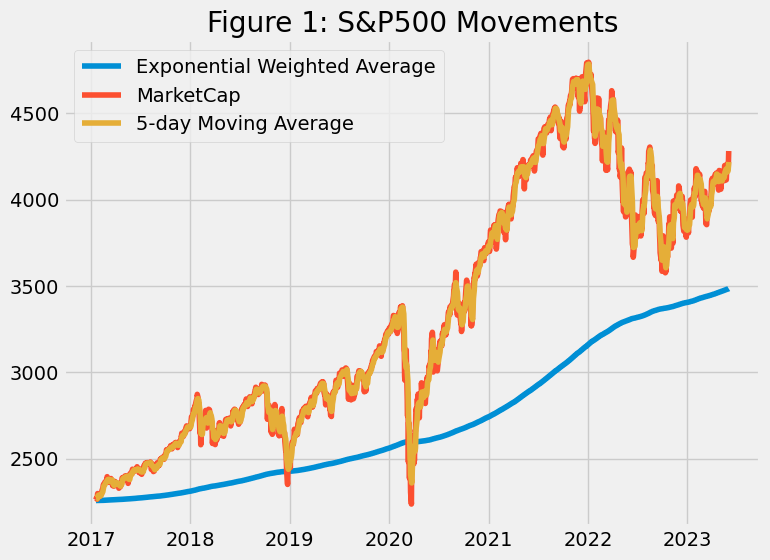

```python
plt.figure(figsize=(8,6))
plt.plot(df.EMA, label='Exponential Weighted Average')
plt.plot(df['Adj Close'], label='MarketCap')
plt.plot(df.SMA_5, label = '5-day Moving Average')
plt.legend()
plt.title('Figure 1: S&P500 Movements')
```

The figure above shows roughly the movement of price of S&P5000. Most of the features has meaningless graphing, and so would not display here.

## 3. Feature Engineering / Feature Selection

The feature selection process should be done after the train/test split.

1. `Filter Method` are used to such as removing features with low variance, univariate feature selection, and multicollinearity reduction, etc.
   - We are trying to reduce features that have low variance as it may contain less information and less variation for classification.
   - Univariate feature selection is used when we run statistic test on a certain factor perse. Ranking those test score, and select most desirable ones.
2. `Wrapper Method` is recursively conducted to reduce the number of features.
3. `Embedded Method` incorporate feature selection directly into the learning algorithm. In our case, the SVM model would be used to select features.

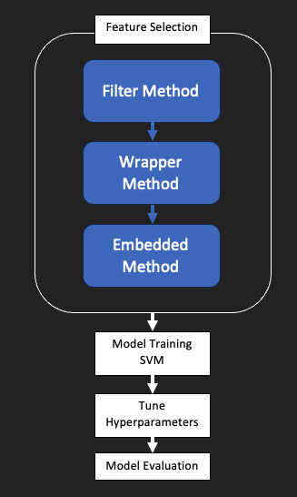

We would select features based on the train-set data only, to avoid including too much information of the test-set. The train/test split percentage is 30%. For the time series data, timing is meaningful, so we would not shuffle the sample.

The cell below displays that date of train/test split is 6th July 2021.

```python
# Split the train / test set
test_set_percent = 0.3

split_date = y.index[int(y.count()*(1 - test_set_percent))]
print('the splite date is :', split_date)

X_train = X.loc[X.index <= split_date]
X_test = X.loc[X.index > split_date]
y_train = y[y.index <= split_date]
y_test = y[y.index > split_date]
```

```
the splite date is : 2021-07-06 00:00:00
```

### 3. (a) Filter Method

`Filter Method` are used to such as removing features with low variance, univariate feature selection, and multicollinearity reduction, etc. The Filter method I used here is the `SelectKBest`.

Since we are focus on the classifier 'SVM' for classification, we would use Chi-Squared statistics as the score. The `Pipeline` class is applied to package (1) a Scaling process and (2) a model-fitting process, because SVM normally requires inputs to be scales.

As I have created too much features before, I would discard some step by step during the feature selecting part.

```python
from sklearn.preprocessing import MinMaxScaler
from sklearn.pipeline import Pipeline

from sklearn.feature_selection import SelectKBest
from sklearn.feature_selection import chi2 # the chi-squared statistics is applied
from sklearn.svm import SVC

from sklearn.model_selection import cross_val_score
```

```python
pipe = Pipeline([
    ('scaler', MinMaxScaler()),  # MinMaxScaler for feature scaling
    ('svm', SVC(kernel='linear'))  # SVM classifier
])

svm = SVC()

minmax = MinMaxScaler()

# SelectKBest require inputs to be non-negative,
# , so we re-scale X
X_train_scaled = minmax.fit_transform(X_train)

score_base = cross_val_score(pipe, X_train, y_train, cv=5).mean()
```

```python
# the number of feature selected from SelectKBest
k = 20

# Create SelectKBest with chi-squared score as the scoring function
skbest = SelectKBest(score_func=chi2, k=k)  # Select top 20 features
skbest.fit(X_train_scaled, y_train)

X_skb = X_train.iloc[:, skbest.get_support()]

# Iterate the score
for f, s in zip(X_train.columns, skbest.scores_):
    print(f'F-score: {s:0.4} for feature {f}')


score_skb = cross_val_score(pipe, X_skb, y_train, cv=5).mean()

print('-'*50)
print('Those selected features are:', X_skb.columns)
```

```
F-score: 0.03531 for feature O-C
F-score: 2.269 for feature H-L
F-score: 0.03004 for feature sign
F-score: 0.03375 for feature PastReturn_1
F-score: 0.02575 for feature Momentum_1
F-score: 0.6218 for feature SMA_1
F-score: 3.376e-05 for feature PastReturn_2
F-score: 0.0006739 for feature Momentum_2
F-score: 0.6149 for feature SMA_2
F-score: 0.005637 for feature PastReturn_3
F-score: 0.0007297 for feature Momentum_3
F-score: 0.6383 for feature SMA_3
F-score: 0.002053 for feature PastReturn_4
F-score: 0.00885 for feature Momentum_4
F-score: 0.655 for feature SMA_4
F-score: 0.00617 for feature PastReturn_5
F-score: 0.01365 for feature Momentum_5
F-score: 0.6774 for feature SMA_5
F-score: 0.05334 for feature PastReturn_6
F-score: 0.004872 for feature Momentum_6
F-score: 0.6998 for feature SMA_6
F-score: 0.004685 for feature PastReturn_7
F-score: 0.03844 for feature Momentum_7
F-score: 0.7107 for feature SMA_7
F-score: 0.0445 for feature PastReturn_8
F-score: 0.02021 for feature Momentum_8
F-score: 0.7381 for feature SMA_8
F-score: 0.01215 for feature PastReturn_9
F-score: 0.07461 for feature Momentum_9
F-score: 0.7563 for feature SMA_9
F-score: 0.01638 for feature PastReturn_10
F-score: 0.03417 for feature Momentum_10
F-score: 0.7851 for feature SMA_10
F-score: 1.497 for feature EMA
--------------------------------------------------
Those selected features are: Index(['O-C', 'H-L', 'sign', 'PastReturn_1', 'SMA_1', 'SMA_2', 'SMA_3',
       'SMA_4', 'SMA_5', 'PastReturn_6', 'SMA_6', 'Momentum_7', 'SMA_7',
       'PastReturn_8', 'SMA_8', 'Momentum_9', 'SMA_9', 'Momentum_10', 'SMA_10',
       'EMA'],
      dtype='object')
```

### 3. (b) Wrapper Method

The Wrapper Methods I would like to use here are `RFECV`. The wrapper method could recursively the number of features. I would run the wrapper method to focus on less features based on the features selection by the filter method,

By the way, `RFECV` requires some attributes existed only when the SVM uses only linear kernel. We pass the features selected from the filter method, and conduct the wrapper method thereafter. 10 features are selected in this step.

```python
from sklearn.feature_selection import RFECV

svm_linear = SVC(kernel='linear')
```

```python
%%time

k = 10

# scale
X_skb_scaled = minmax.fit_transform(X_skb)

# caution! RFE using the recurrsive algorithm, so it really takes times
rfe = RFECV(estimator=svm_linear, min_features_to_select=k, cv = 5)
rfe.fit(X_skb_scaled,y_train)

X_rfe = X_skb.iloc[:, rfe.support_]

print(X_rfe.columns)

score_rfe = cross_val_score(pipe, X_rfe, y_train, cv=5).mean()
```

```
Index(['PastReturn_1', 'SMA_1', 'SMA_2', 'SMA_3', 'SMA_4', 'SMA_5', 'SMA_6',
       'SMA_7', 'SMA_9', 'SMA_10'],
      dtype='object')
CPU times: user 2.76 s, sys: 1 s, total: 3.77 s
Wall time: 768 ms
```

### 3.(c) Embedded Method

`Embedded Method` incorporate feature selection directly into the learning algorithm. In our case, the SVM model with a linear kernal would be used to select features. Maximum 5 fearures are selected in this stage.

`L1` & `L2` are used here. Embedded method means incorporating feature selection directly into the SVM in our case. We only use the `L1` result, those features selected are finally 'PastReturn_1', 'SMA_3', 'SMA_10'.

```python
from sklearn.feature_selection import SelectFromModel
from sklearn.svm import LinearSVC
```

```python
k = 5
# scale
X_rfe_scaled = minmax.fit_transform(X_rfe)

# Create an SVM model with L1 regularization
svm_l1 = LinearSVC(penalty="l1", dual=False)
svm_l1.fit(X_rfe_scaled, y_train)
svm_l2 = LinearSVC(penalty="l2")
svm_l2.fit(X_rfe_scaled, y_train)

# Use SelectFromModel to select features based on the L1 regularization
model_l1 = SelectFromModel(svm_l1, prefit=True, max_features=k)
X_l1 = X_rfe.iloc[:,model_l1.get_support()]

model_l2 = SelectFromModel(svm_l2, prefit=True,  max_features=k)
X_l2 = X_rfe.iloc[:,model_l2.get_support()]

print('l1-norm selected features are:',X_l1.columns)
score_l1 = cross_val_score(pipe, X_l1, y_train, cv=5).mean()

print('-'*50)
# print('l2-norm selected features are:', X_l2.columns)
score_l2 = cross_val_score(pipe, X_l2, y_train, cv=5).mean()
```

```
l1-norm selected features are: Index(['PastReturn_1', 'SMA_3', 'SMA_10'], dtype='object')
--------------------------------------------------
```

# B. Model Building and Evaluation

After the embedded method of L1-regularisation, those features selected are 'PastReturn_1', 'SMA_3', 'SMA_10'.

## 4. (a) produce a model to predict positive moves (up trend) using support vector machine algorithm.

We here would predict the result by inputting different types of regressors.

```python
# for scoring
from sklearn.metrics import (accuracy_score,
                             f1_score,
                             recall_score,
                             precision_score,
                             roc_auc_score,
                             auc)

# for displaying
from sklearn.metrics import (precision_recall_curve,
                             roc_curve,
                             RocCurveDisplay,
                             ConfusionMatrixDisplay)

from sklearn.metrics import (classification_report,
                             confusion_matrix)
```

### The accuracy score

```python
X_skb_test = X_test[X_skb.columns]
X_rfe_test = X_test[X_rfe.columns]
X_l1_test = X_test[X_l1.columns]
X_l2_test = X_test[X_l2.columns]
```

```python
def print_accuracy_score(model, X_train, y_train, X_test, y_test):
    model.fit(X_train, y_train)
    y_pred = model.predict(X_test)

    acc_train = accuracy_score(y_train, model.predict(X_train))
    acc_test = accuracy_score(y_test, y_pred)

    print(f'Train Accuracy: {acc_train:0.4}, Test Accuracy: {acc_test:0.4}')


#####

model = SVC(kernel='sigmoid',
            probability=True)
pipe = Pipeline([
    ('scaler', MinMaxScaler()),  # MinMaxScaler for feature scaling
    ('svm', model)  # SVM classifier
])


# filter - SelectKBest
print('-'*50)
print('Filter Method: skb:')
print_accuracy_score(pipe, X_skb, y_train, X_skb_test, y_test)

# Wrapper Method - RFE
print('-'*50)
print('Wrapper Method: rfe:')
print_accuracy_score(pipe, X_rfe, y_train, X_rfe_test, y_test)

# Embeded Method - l1
print('-'*50)
print('Embedded Method: l1:')
print_accuracy_score(pipe, X_l1, y_train, X_l1_test, y_test)

# embeded - l2
print('-'*50)
print('Embedded Method: l2:')
print_accuracy_score(pipe, X_l2, y_train, X_l2_test, y_test)
```

```
--------------------------------------------------
Filter Method: skb:
Train Accuracy: 0.6714, Test Accuracy: 0.4449
--------------------------------------------------
Wrapper Method: rfe:
Train Accuracy: 0.626, Test Accuracy: 0.4012
--------------------------------------------------
Embedded Method: l1:
Train Accuracy: 0.6794, Test Accuracy: 0.4304
--------------------------------------------------
Embedded Method: l2:
Train Accuracy: 0.6269, Test Accuracy: 0.4012
```

### Confusion Matrix

```python
pipe.fit(X_l1, y_train)

# Predicting the test dataset
y_pred = pipe.predict(X_l1_test)

# Predict Probabilities
y_proba = pipe.predict_proba(X_l1_test)
```

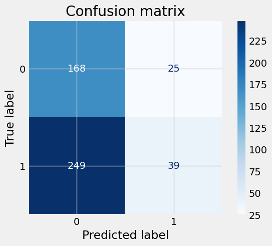

```python
# Display confussion matrix
disp = ConfusionMatrixDisplay.from_estimator(
        pipe,
        X_l1_test,
        y_test,
        display_labels = pipe.classes_,
        cmap=plt.cm.Blues
    )
disp.ax_.set_title('Confusion matrix')
plt.show()
```

### Classification Report

```python
# Classification Report
print(classification_report(y_test, y_pred))
```

```
              precision    recall  f1-score   support

           0       0.40      0.87      0.55       193
           1       0.61      0.14      0.22       288

    accuracy                           0.43       481
   macro avg       0.51      0.50      0.39       481
weighted avg       0.53      0.43      0.35       481
```

From the confusion matrix and classification report, we can find that the type 1 error (precision) is not bad, but the recall rate is terrible. The overall accuracy is 0.43, which is even less than 50%-50% gamble. Model prediction is not comfortable.

### ROC Curve

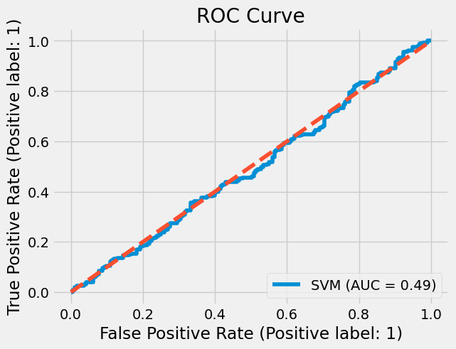

```python
# Display ROCCurve
disp_roc = RocCurveDisplay.from_estimator(
            pipe,
            X_l1_test,
            y_test,
            name='SVM')
disp_roc.ax_.set_title('ROC Curve')
plt.plot([0,1], [0,1], linestyle='--')
plt.show()
```

From the ROC curve, we can find that the blue curve (SVM result) cannot be clearly distinguished from the base-line.

The model prediction is not that good, and so we would grid-search hyperparamter to find if there is any importment from the model hyperparameter aspect.

## 4. (b) tune hyperparameters for the estimator to present an optimal model.

SVM has hyper-parameters are:

- C: [0.01, 0.1, 0.2, 0.5, 0.8, 0.9, 1]
- gamma: [0.01, 0.1, 0.2, 0.5, 0.8, 0.9, 1, 'auto']
- kernel: ['linear', 'rbf', 'sigmoid']

```python
from sklearn.model_selection import GridSearchCV

# defining parameter range
param_grid = {'C': [0.01, 0.1, 0.2, 0.5, 0.8, 0.9, 1],
              'gamma': [0.01, 0.1, 0.2, 0.5, 0.8, 0.9, 1, 'auto'],
              'kernel': ['linear', 'rbf', 'sigmoid']}

X_l1_scaled = minmax.fit_transform(X_l1)
```

```python
%%time
grid = GridSearchCV(SVC(), param_grid, refit = True, cv=3, verbose=3)

# fitting the model for grid search
grid.fit(X_l1_scaled, y_train)
```

[output not shown]

[output cut: 452 more lines]

```
[CV 3/3] END ..........C=1, gamma=1, kernel=rbf;, score=0.733 total time=   0.0s
[CV 1/3] END ......C=1, gamma=1, kernel=sigmoid;, score=0.283 total time=   0.0s
[CV 2/3] END ......C=1, gamma=1, kernel=sigmoid;, score=0.735 total time=   0.0s
[CV 3/3] END ......C=1, gamma=1, kernel=sigmoid;, score=0.733 total time=   0.0s
[CV 1/3] END ....C=1, gamma=auto, kernel=linear;, score=0.733 total time=   0.0s
[CV 2/3] END ....C=1, gamma=auto, kernel=linear;, score=0.735 total time=   0.0s
[CV 3/3] END ....C=1, gamma=auto, kernel=linear;, score=0.733 total time=   0.0s
[CV 1/3] END .......C=1, gamma=auto, kernel=rbf;, score=0.733 total time=   0.0s
[CV 2/3] END .......C=1, gamma=auto, kernel=rbf;, score=0.735 total time=   0.0s
[CV 3/3] END .......C=1, gamma=auto, kernel=rbf;, score=0.733 total time=   0.0s
[CV 1/3] END ...C=1, gamma=auto, kernel=sigmoid;, score=0.733 total time=   0.0s
[CV 2/3] END ...C=1, gamma=auto, kernel=sigmoid;, score=0.735 total time=   0.0s
[CV 3/3] END ...C=1, gamma=auto, kernel=sigmoid;, score=0.733 total time=   0.0s
CPU times: user 4.01 s, sys: 14.6 ms, total: 4.03 s
Wall time: 3.61 s
```

```
GridSearchCV(cv=3, estimator=SVC(),
             param_grid={'C': [0.01, 0.1, 0.2, 0.5, 0.8, 0.9, 1],
                         'gamma': [0.01, 0.1, 0.2, 0.5, 0.8, 0.9, 1, 'auto'],
                         'kernel': ['linear', 'rbf', 'sigmoid']},
             verbose=3)
```

```python
# best parameters
grid.best_params_
```

```
{'C': 0.01, 'gamma': 0.01, 'kernel': 'linear'}
```

```python
# score while applying grid-serach result
grid.best_score_
```

```
0.733749257278669
```

The grid-search gives up the best parameters in our list, and the corresponding score.

The best parameters are: {'C': 0.01, 'gamma': 0.01, 'kernel': 'linear'}.

The best score is 0.7337.

## 4. (c) investigate model prediction quality using area under receiver operating characteristic curve, confusion matrix and classiﬁcation report.

Applying the grid-serach result as the parameters of the SVM model, we could present the confusion matrix, classification report, ROC curve again.

```python
model_tuned = SVC(**grid.best_params_, probability=True)
pipe_tuned = Pipeline([
    ('scaler', MinMaxScaler()),  # MinMaxScaler for feature scaling
    ('svm', model_tuned)  # SVM classifier
])

pipe_tuned.fit(X_l1, y_train)
```

```
Pipeline(steps=[('scaler', MinMaxScaler()),
                ('svm',
                 SVC(C=0.01, gamma=0.01, kernel='linear', probability=True))])
```

### Confusion Matrix

```python
# Predicting the test dataset
y_pred = pipe_tuned.predict(X_l1_test)

# Predict Probabilities
y_proba = pipe_tuned.predict_proba(X_l1_test)
```

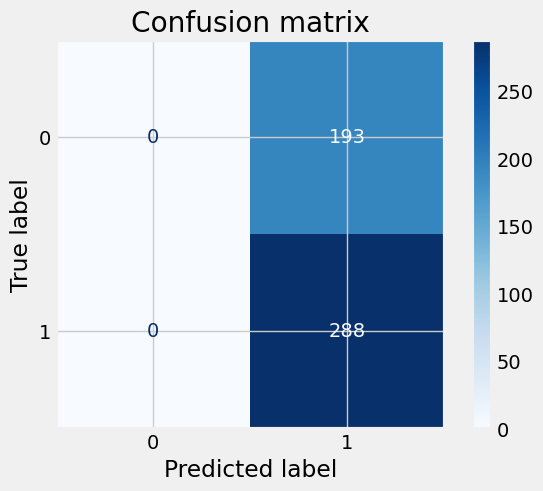

```python
# Display confussion matrix
disp = ConfusionMatrixDisplay.from_estimator(
        pipe_tuned,
        X_l1_test,
        y_test,
        display_labels=pipe_tuned.classes_,
        cmap=plt.cm.Blues
    )
disp.ax_.set_title('Confusion matrix')
plt.show()
```

### Classification Report

```python
# Classification Report
print(classification_report(y_test, y_pred))
```

```
              precision    recall  f1-score   support

           0       0.00      0.00      0.00       193
           1       0.60      1.00      0.75       288

    accuracy                           0.60       481
   macro avg       0.30      0.50      0.37       481
weighted avg       0.36      0.60      0.45       481
```

```python
print('The probability of S&P500 price moving upward')
print('training period:', round(y_train.sum()/len(y_train),4))
print('testing period', round(y_test.sum()/len(y_test),4))
print('2017-2023 whole period:', round(y.sum()/len(y),4))
```

```
The probability of S&P500 price moving upward
training period: 0.7337
testing period 0.5988
2017-2023 whole period: 0.6933
```

However, from the above validity results, we can find that the accuracy score equals exactly to the probability of all y = 1. In other words, our model predicts the price will move up in any scenarios.

### ROC Curve

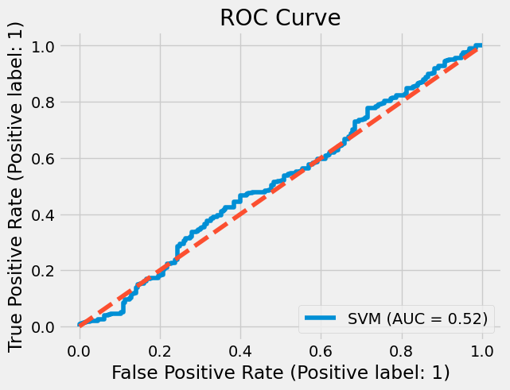

```python
# Display ROCCurve
disp_roc = RocCurveDisplay.from_estimator(
            pipe_tuned,
            X_l1_test,
            y_test,
            name='SVM')
disp_roc.ax_.set_title('ROC Curve')
plt.plot([0,1], [0,1], linestyle='--')
plt.show()
```

The ROC curve shows that the model after using tuned hyperparameters performed better than the previous one. However, combining with the fact that model predicts all y=1, we cannot tell whether the model is good or bad. The feature selection process might still not good, becuase all y=1 means the prediction would be one regardless the value of inputs. In Finance or Investment, that might work when the overall market is good, but is definitly trouble making if the market is in bear.